# AF vs dementia, by sex

```r
knitr::opts_chunk$set(echo = TRUE, warning=FALSE, message=F)
```

**Libraries**

```r
#install.packages("packages/rmarkdown_2.14.tar.gz", repos=NULL)

library(tidyverse)
library(survival)   # survival analysis
library(data.table) # fread() function
library(gridExtra)  # plots to grid
library(survminer)  # ggbased visualization and extra diagnostics
library(visdat)     # visualization of tibble and na's
library(kableExtra) # Pretty tables
library(tableone)   # Characteristics table
library(forestplot) # forestplot

fg_pheno_path <- "/finngen/library-red/finngen_R9/phenotype_1.0/data"
data_path <- "data"
fig_path <- "figs2"
#font_size <- 12

source("scripts/functions.R")
```

# 1 Data

## 1.1 Definitions

This is sex stratified version of the analysis.

**Outcomes**

- Any dementia (KRA_PSY_DEMENTIA)
- Alzheimer disease (G6_ALZHEIMER)
- Vascular dementia (F5_VASCDEM)

**Exposures**

- Heart failure (I9_HEARTFAIL_ALLCAUSE)
- Atrial fibrillation (I9_AF)
- Myocardial infarction (I9_MI)
- Peripheral arterial disease (I9_PAD)
- Stroke (I9_STR)
- TIA (I9_TIA)

**Covariates**

Age is not included as we do not have explicit baseline.  
Dementia age is taken account by using age as time scale. Birth year is included to take account cohort effects. Disease covariates are treated as time varied covariates.

- Birth year, (SD)
- Smoking, n (%)

Disease covariates

- Obesity (E4_OBESITY), n (%)
- Hyperlipidemia (E4_HYPERLIPMIX|RX_STATIN), n (%)
- Chronic kidney disease (N14_CHRONKIDNEYDIS), n (%)
- Hypertension (I9_HYPERTENSION), n (%)
- Diabetes (E4_DIABETES), n (%)
- Alcohol abuse (AUD), n (%)

## 1.2 Variable lists

```r
nicenames <- c(DEMENTIA = "Any dementia", ALZHEIMER = "Alzheimer disase", VASCDEM = "Vascular dementia",
               AF_TDC = "Atrial fibrillation", OBESITY_TDC = "Obesity",
               HYPLIP_WIDE_TDC = "Hyperlipidemia", HEARTFAIL_ALLCAUSE_TDC="Heart failure",
               MI_TDC = "Myocardial infarction", CHRONKIDNEYDIS_TDC = "Chronic kidney disease",
               HYPERTENSION_TDC = "Hypertension", DIABETES_TDC = "Diabetes", STR_TDC = "Stroke",
               STR_EMBOLIC_TDC = "Embolic stroke", TIA_TDC = "TIA",
               AUD_TDC = "Alcohol abuse", PAD_TDC = "PAD")

#Outcomes
names_ep <- list("DEMENTIA", "ALZHEIMER", "VASCDEM")
ep_age <-   str_replace(unlist(names_ep), "(.*)", "\\1_AGE")

#time dependent variables
tdc_vars <- c("AF_TDC","OBESITY_TDC", "HYPLIP_WIDE_TDC", "HEARTFAIL_ALLCAUSE_TDC", "MI_TDC",
             "CHRONKIDNEYDIS_TDC", "HYPERTENSION_TDC", "DIABETES_TDC", "STR_TDC",
             "TIA_TDC", "AUD_TDC", "PAD_TDC")
tdc_vars_ever <- str_remove(tdc_vars, "_TDC")
tdc_vars_age <- str_replace(tdc_vars, "_TDC", "_AGE")
tdc_vars2 <- c("HEARTFAIL_ALLCAUSE_TDC", "AF_TDC", "MI_TDC", "PAD_TDC", "STR_TDC" , "TIA_TDC")


#Other covariates
oth_covs <- c("BIRTH_YEAR", "SMOKED")
oth_covs2 <- c(oth_covs, "OBESITY_TDC",  "HYPLIP_WIDE_TDC", "CHRONKIDNEYDIS_TDC", "HYPERTENSION_TDC", "DIABETES_TDC", "AUD_TDC")


#Study start year
start_year = 1998
```

## 1.3 Preselect phenotype columns

Entries of interest from endpoint file are preselected at ‘rather big machine’, because the original phenotype file is very large.

```r
pheno_cols <- fread("data/variables.txt") %>%
  mutate(col_age = str_glue("{column}_AGE")) %>%
  mutate(col_year = str_glue("{column}_YEAR"))

pheno_cols_all <- c(pheno_cols$column, pheno_cols$col_age, pheno_cols$col_year)

pheno_tmp <- fread(str_glue("{fg_pheno_path}/finngen_R9_endpoint_1.0.txt.gz")) %>%
  select(FINNGENID, FU_END_AGE, all_of(pheno_cols_all))

fwrite(pheno_tmp, 'data/finngen_R9_myvars.tsv.gz', sep='\t')
```

## 1.4 Read in and preprocess

```r
#disease variables
phenotypes <- fread("data/finngen_R9_myvars.tsv.gz") %>%

  #Names are simplified
  rename_at(vars(matches("^[A-Z][0-9]+_")), list(~str_remove(., "^[A-Z][0-9]+_"))) %>%
  rename_at(vars(starts_with('KRA_PSY_')), list(~str_remove(., "KRA_PSY_"))) %>%
  rename_at(vars(starts_with('C_')), list(~str_remove(., "C_"))) %>%
  rename_at(vars(starts_with('DM_')), list(~str_remove(., "DM_"))) %>%
  rename_at(vars(starts_with('RX_')), list(~str_remove(., "RX_"))) %>%

  #Wider definition of hypercholesterolaemia, includes also statin medication
  mutate(HYPLIP_WIDE = if_else(HYPERLIPMIX == 1 | STATIN == 1, 1L, 0L)) %>%
  rowwise() %>%
    mutate(HYPLIP_WIDE_AGE = min(HYPERLIPMIX_AGE, STATIN_AGE)) %>%
  ungroup() %>%

  #Change NA -> 0 for disease variables
  #FinnGen data is constructed for GWASes, where similar diseases need to be removed from controls
  #This does not apply to present study
   mutate_at(c(unlist(names_ep), tdc_vars_ever), ~if_else(is.na(.), 0L, .))


#other covariates
phenomin <- fread(str_glue("{fg_pheno_path}/finngen_R9_minimum_1.0.txt.gz")) %>%
  select("FINNGENID", contains("BL_"), "SEX", "SMOKE3", "SMOKE_AGE", "movedabroad") %>%
  #smoking: ever-never according phenotype minimal file
  mutate(SMOKED = if_else(SMOKE3 == "never", 0, 1)) %>%
  #Approximate birth year calculated from BL_YEAR and BL_AGE
  mutate(BIRTH_YEAR = BL_YEAR - BL_AGE,     #genotyping year and age
         START_AGE = if_else(floor(BIRTH_YEAR) < start_year, start_year-BIRTH_YEAR, 0),
         BIRTH_YEAR = as.integer(floor(BIRTH_YEAR)))

#Imputed sex is from genotyped dataset
sex_in <- fread(str_glue("/finngen/library-red/finngen_R9/analysis_covariates/R9_COV_V1.FID.txt.gz")) %>%
  select(IID, SEX_IMPUTED) %>%
  rename(FINNGENID = IID) %>%
  rename(WOMEN = SEX_IMPUTED)
```

## 1.5 Combine & filter

**All**

```r
df.tmp1 <-phenomin %>%
  right_join(sex_in, by = "FINNGENID") %>%   #This represent official genotyped dataset
  left_join(phenotypes, by = "FINNGENID")
df.tmp1 %>% select("WOMEN") %>% mutate_all(as.factor) %>% summary
```

```
##  WOMEN
##  0:166407
##  1:210870
```

**Remove individual with no “FU_END_AGE” i.e. individuals missing from endpoint-file**

```r
#Remove individual with no "FU_END_AGE" i.e. individuals missing from endpoint-file
df.tmp2 <- df.tmp1 %>%
  filter(!is.na(FU_END_AGE))
df.tmp2 %>% select("WOMEN") %>% mutate_all(as.factor) %>% summary
```

```
##  WOMEN
##  0:166407
##  1:210870
```

**Remove if no smoking record**

```r
#Remove individual if no smoking record
df.tmp3 <- df.tmp2 %>%
  filter(!is.na(SMOKED))
df.tmp3 %>% select("WOMEN") %>% mutate_all(as.factor) %>% summary
```

```
##  WOMEN
##  0:105892
##  1:115870
```

Full register coverage starts from this year.

```r
#Remove individual if any dementia before 'start year'
df <- df.tmp3 %>%
  filter(DEMENTIA_AGE > START_AGE+0.003 & ALZHEIMER_AGE > START_AGE+0.003 & VASCDEM_AGE > START_AGE+0.003)
  #0.003 years = one day; coxph would inteprete very short time difference 0 time followup
df %>% select("WOMEN") %>% mutate_all(as.factor) %>% summary
```

```
##  WOMEN
##  0:102475
##  1:115717
```

## 1.6 Variables to list by outcome

Minor formatting

```r
#Minor formatting for more clear summaries etc
df <- df %>%
  mutate_at(unlist(names_ep), ~as.integer(as.character(.)) ) %>%
  mutate_at(c(tdc_vars_ever), as.factor) %>%
  select(FINNGENID, WOMEN, all_of(oth_covs), FU_END_AGE, START_AGE, BIRTH_YEAR, all_of(unlist(names_ep)), all_of(ep_age),
         all_of(tdc_vars_ever), all_of(tdc_vars_age))
```

**As time varied variable**

All

```r
df.list.tdc <- lapply(names_ep, as.null) %>% setNames(names_ep)

for(ep in unlist(names_ep)){

  #ep = "DEMENTIA"
  ep_age_tmp <- as.character(str_glue("{ep}_AGE"))
  dfi <- df  #%>% slice(1:30)
  #print(ep)

  dfi.tmp   <- tmerge(data1=dfi,   data2=dfi, id=FINNGENID, tstart = START_AGE, tstop = get(ep_age_tmp),
                      event=event(get(ep_age_tmp), get(ep)))

  for(var in tdc_vars_ever){
    #var %>% print()
    dfi.tmp  <- tmerge(data1=dfi.tmp, data2=dfi, id=FINNGENID, tdc_var = tdc(get(str_glue("{var}_AGE")))) %>%
      rename(!!str_glue("{var}_TDC") := tdc_var)
  }

  df.list.tdc[[ep]] <- dfi.tmp %>%
    filter(tstop > tstart+0.003) %>%  #0.003 years = one day; coxph would inteprete very short time difference 0 time followup
    mutate(time_test = tstop - tstart)
}
```

Women

```r
df.list.tdc.f <- lapply(df.list.tdc, function(dfi) {dfi %>% filter(WOMEN==1)})
```

Men

```r
df.list.tdc.m <- lapply(df.list.tdc, function(dfi) {dfi %>% filter(WOMEN==0)})
```

## 1.7 Characteristics

### 1.7.1 Dementia

```r
ep <- "DEMENTIA"
vars <- c(ep,  "END_AGE", oth_covs, tdc_vars)
fact_vars <- c(ep, "SMOKED", tdc_vars)

#Women
df.tmp <- df.list.tdc.f[[ep]] %>%
  select(FINNGENID, all_of(c(ep, str_glue("{ep}_AGE"), oth_covs, tdc_vars))) %>%
  group_by(FINNGENID) %>%
  summarise_all(max) %>%   #For 'tdc variables'  we want maximum (1 if any of the rows have 1), others should be the same in all rows an individual.
  rename(END_AGE = str_glue("{ep}_AGE"))

table.f <- CreateTableOne(vars=vars, data=df.tmp, factorVars = fact_vars, test=F) %>%
  print(dropEqual=T, printToggle=F, contDigits=1)
colnames(table.f) <- c("Women")


#Men
df.tmp <- df.list.tdc.m[[ep]] %>%
  select(FINNGENID, all_of(c(ep, str_glue("{ep}_AGE"), oth_covs, tdc_vars))) %>%
  group_by(FINNGENID) %>%
  summarise_all(max) %>%   #For 'tdc variables'  we want maximum (1 if any of the rows have 1), others should be the same in all rows an individual.
  rename(END_AGE = str_glue("{ep}_AGE"))

table.m <- CreateTableOne(vars=vars, data=df.tmp, factorVars = fact_vars, test=F) %>%
  print(dropEqual=T, printToggle=F, contDigits=1)
colnames(table.m) <- c("Men")


#Combine
cbind(table.f, table.m) %>%
  my.kable
```

|  | Women | Men |
| --- | --- | --- |
| n | 115717 | 102475 |
| DEMENTIA (%) | 3471 ( 3.0) | 6230 ( 6.1) |
| END_AGE (mean (SD)) | 58.6 (17.5) | 65.2 (16.0) |
| BIRTH_YEAR (mean (SD)) | 1961.6 (18.2) | 1952.9 (18.4) |
| SMOKED (%) | 45909 (39.7) | 63553 (62.0) |
| AF_TDC (%) | 9224 ( 8.0) | 17916 (17.5) |
| OBESITY_TDC (%) | 7983 ( 6.9) | 4428 ( 4.3) |
| HYPLIP_WIDE_TDC (%) | 32413 (28.0) | 43245 (42.2) |
| HEARTFAIL_ALLCAUSE_TDC (%) | 5485 ( 4.7) | 11358 (11.1) |
| MI_TDC (%) | 4035 ( 3.5) | 12151 (11.9) |
| CHRONKIDNEYDIS_TDC (%) | 1499 ( 1.3) | 3578 ( 3.5) |
| HYPERTENSION_TDC (%) | 28077 (24.3) | 35411 (34.6) |
| DIABETES_TDC (%) | 15285 (13.2) | 21659 (21.1) |
| STR_TDC (%) | 5354 ( 4.6) | 10088 ( 9.8) |
| TIA_TDC (%) | 4779 ( 4.1) | 6180 ( 6.0) |
| AUD_TDC (%) | 3148 ( 2.7) | 7126 ( 7.0) |
| PAD_TDC (%) | 2887 ( 2.5) | 7609 ( 7.4) |

### 1.7.2 Alzheimer

**Women**

```r
ep <- "ALZHEIMER"
vars <- c(ep,  "END_AGE", oth_covs, tdc_vars)
fact_vars <- c(ep, "SMOKED", tdc_vars)

#Women
df.tmp <- df.list.tdc.f[[ep]] %>%
  select(FINNGENID, all_of(c(ep, str_glue("{ep}_AGE"), oth_covs, tdc_vars))) %>%
  group_by(FINNGENID) %>%
  summarise_all(max) %>%   #For 'tdc variables'  we want maximum (1 if any of the rows have 1), others should be the same in all rows an individual.
  rename(END_AGE = str_glue("{ep}_AGE"))

table.f <- CreateTableOne(vars=vars, data=df.tmp, factorVars = fact_vars, test=F) %>%
  print(dropEqual=T, printToggle=F, contDigits=1)
colnames(table.f) <- c("Women")


#Men
df.tmp <- df.list.tdc.m[[ep]] %>%
  select(FINNGENID, all_of(c(ep, str_glue("{ep}_AGE"), oth_covs, tdc_vars))) %>%
  group_by(FINNGENID) %>%
  summarise_all(max) %>%   #For 'tdc variables'  we want maximum (1 if any of the rows have 1), others should be the same in all rows an individual.
  rename(END_AGE = str_glue("{ep}_AGE"))

table.m <- CreateTableOne(vars=vars, data=df.tmp, factorVars = fact_vars, test=F) %>%
  print(dropEqual=T, printToggle=F, contDigits=1)
colnames(table.m) <- c("Men")


#Combine
cbind(table.f, table.m) %>%
  my.kable
```

|  | Women | Men |
| --- | --- | --- |
| n | 115717 | 102475 |
| ALZHEIMER (%) | 2352 ( 2.0) | 3971 ( 3.9) |
| END_AGE (mean (SD)) | 58.7 (17.6) | 65.3 (16.0) |
| BIRTH_YEAR (mean (SD)) | 1961.6 (18.2) | 1952.9 (18.4) |
| SMOKED (%) | 45909 (39.7) | 63553 (62.0) |
| AF_TDC (%) | 9300 ( 8.0) | 18087 (17.7) |
| OBESITY_TDC (%) | 8005 ( 6.9) | 4439 ( 4.3) |
| HYPLIP_WIDE_TDC (%) | 32478 (28.1) | 43379 (42.3) |
| HEARTFAIL_ALLCAUSE_TDC (%) | 5528 ( 4.8) | 11519 (11.2) |
| MI_TDC (%) | 4084 ( 3.5) | 12253 (12.0) |
| CHRONKIDNEYDIS_TDC (%) | 1520 ( 1.3) | 3656 ( 3.6) |
| HYPERTENSION_TDC (%) | 28178 (24.4) | 35585 (34.7) |
| DIABETES_TDC (%) | 15336 (13.3) | 21748 (21.2) |
| STR_TDC (%) | 5446 ( 4.7) | 10268 (10.0) |
| TIA_TDC (%) | 4821 ( 4.2) | 6254 ( 6.1) |
| AUD_TDC (%) | 3160 ( 2.7) | 7188 ( 7.0) |
| PAD_TDC (%) | 2912 ( 2.5) | 7707 ( 7.5) |

### 1.7.3 Vascular dementia

```r
ep <- "VASCDEM"
vars <- c(ep,  "END_AGE", oth_covs, tdc_vars)
fact_vars <- c(ep, "SMOKED", tdc_vars)

#Women
df.tmp <- df.list.tdc.f[[ep]] %>%
  select(FINNGENID, all_of(c(ep, str_glue("{ep}_AGE"), oth_covs, tdc_vars))) %>%
  group_by(FINNGENID) %>%
  summarise_all(max) %>%   #For 'tdc variables'  we want maximum (1 if any of the rows have 1), others should be the same in all rows an individual.
  rename(END_AGE = str_glue("{ep}_AGE"))

table.f <- CreateTableOne(vars=vars, data=df.tmp, factorVars = fact_vars, test=F) %>%
  print(dropEqual=T, printToggle=F, contDigits=1)
colnames(table.f) <- c("Women")


#Men
df.tmp <- df.list.tdc.m[[ep]] %>%
  select(FINNGENID, all_of(c(ep, str_glue("{ep}_AGE"), oth_covs, tdc_vars))) %>%
  group_by(FINNGENID) %>%
  summarise_all(max) %>%   #For 'tdc variables'  we want maximum (1 if any of the rows have 1), others should be the same in all rows an individual.
  rename(END_AGE = str_glue("{ep}_AGE"))

table.m <- CreateTableOne(vars=vars, data=df.tmp, factorVars = fact_vars, test=F) %>%
  print(dropEqual=T, printToggle=F, contDigits=1)
colnames(table.m) <- c("Men")


#Combine
cbind(table.f, table.m) %>%
  my.kable
```

|  | Women | Men |
| --- | --- | --- |
| n | 115717 | 102475 |
| VASCDEM (%) | 430 ( 0.4) | 1189 ( 1.2) |
| END_AGE (mean (SD)) | 58.7 (17.6) | 65.4 (16.1) |
| BIRTH_YEAR (mean (SD)) | 1961.6 (18.2) | 1952.9 (18.4) |
| SMOKED (%) | 45909 (39.7) | 63553 (62.0) |
| AF_TDC (%) | 9466 ( 8.2) | 18324 (17.9) |
| OBESITY_TDC (%) | 8015 ( 6.9) | 4443 ( 4.3) |
| HYPLIP_WIDE_TDC (%) | 32531 (28.1) | 43431 (42.4) |
| HEARTFAIL_ALLCAUSE_TDC (%) | 5623 ( 4.9) | 11711 (11.4) |
| MI_TDC (%) | 4155 ( 3.6) | 12411 (12.1) |
| CHRONKIDNEYDIS_TDC (%) | 1553 ( 1.3) | 3715 ( 3.6) |
| HYPERTENSION_TDC (%) | 28348 (24.5) | 35797 (34.9) |
| DIABETES_TDC (%) | 15391 (13.3) | 21794 (21.3) |
| STR_TDC (%) | 5556 ( 4.8) | 10462 (10.2) |
| TIA_TDC (%) | 4865 ( 4.2) | 6335 ( 6.2) |
| AUD_TDC (%) | 3169 ( 2.7) | 7190 ( 7.0) |
| PAD_TDC (%) | 2949 ( 2.5) | 7761 ( 7.6) |

# 2 Analysis

## 2.1 Kaplan Meier

### 2.1.1 Models

Let’s see raw data and examine proportional hazard assumption

Surv(tstart, tstop, event) ~ {var_tdc} + WOMEN)

```r
ep="DEMENTIA"

km.l.d <-
  lapply(as.list(tdc_vars), function(var){

    my_formula <- str_glue("Surv(tstart, tstop, event) ~ {var} + WOMEN")
    survfit(as.formula(my_formula), data=df.list.tdc[[ep]])

  }) %>% setNames(tdc_vars)


ep <-  "ALZHEIMER"

km.l.a <-
  lapply(as.list(tdc_vars), function(var){

    my_formula <- str_glue("Surv(tstart, tstop, event) ~ {var} + WOMEN")
    survfit(as.formula(my_formula), data=df.list.tdc[[ep]])

  }) %>% setNames(tdc_vars)


ep <- "VASCDEM"

km.l.v <-
  lapply(as.list(tdc_vars), function(var){

    my_formula <- str_glue("Surv(tstart, tstop, event) ~ {var} + WOMEN")
    survfit(as.formula(my_formula), data=df.list.tdc[[ep]])

  }) %>% setNames(tdc_vars)
```

### 2.1.2 Kaplan Meier summary figure

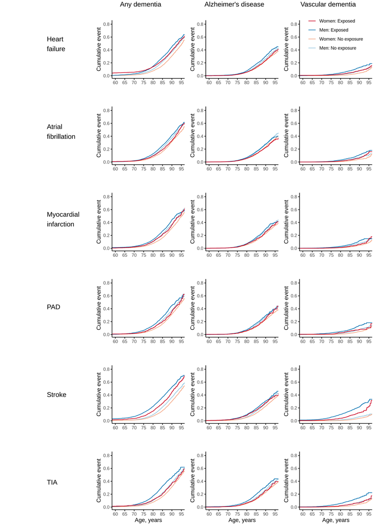

```r
nicenames <- c(DEMENTIA = "Any dementia", ALZHEIMER = "Alzheimer disase", VASCDEM = "Vascular dementia",
               AF_TDC = "Atrial\nfibrillation", OBESITY_TDC = "Obesity",
               HYPLIP_WIDE_TDC = "Hyperlipidemia", HEARTFAIL_ALLCAUSE_TDC="Heart\nfailure",
               MI_TDC = "Myocardial\ninfarction", CHRONKIDNEYDIS_TDC = "Chronic kidney disease",
               HYPERTENSION_TDC = "Hypertension", DIABETES_TDC = "Diabetes", STR_TDC = "Stroke",
               STR_EMBOLIC_TDC = "Embolic stroke", TIA_TDC = "TIA",
               AUD_TDC = "Alcohol abuse", PAD_TDC = "PAD")
fontsize <- 13
palette <- c("#92C5DE","#F4A582","#0571B0","#CA0020")
legend.labs <- c("Men: No exposure","Women: No exposure", "Men: Exposed", "Women: Exposed")

#Exposure labels
exp.labs.l <- lapply(as.list(tdc_vars2), function(var){
  text_grob(nicenames[var], just="left", size=fontsize)
})
p0 <- arrangeGrob(grobs=exp.labs.l, ncol=1)

#Dementia
ep="DEMENTIA"
var="AF_TDC"  #Without initialization loop fails, which is strange
my_formula <- str_glue("Surv(tstart, tstop, event) ~ {var}")

plots.kms <-   lapply(as.list(tdc_vars2), function(var){

  my.km <-
    ggsurvplot(km.l.d[[var]], fun="event", conf.int=F, censor=F,
       xlim=c(60,95), ylim=c(0,0.82), break.x.by=5, break.y.by=0.2,
       title = "", xlab = "", legend="none", legend.labs=legend.labs,
       ggtheme = theme_classic(), palette = palette, size = 0.5)$plot
}) %>% setNames(as.list(tdc_vars2))
#xlab only to bottom row (TIA)
plots.kms$TIA_TDC <- plots.kms$TIA_TDC +
  xlab("Age, years")

p1 <- arrangeGrob(grobs=plots.kms, ncol=1, top=text_grob("Any dementia", size=fontsize))


#Alzheimer
ep="ALZHEIMER"
var="AF_TDC"  #Without initialization loop fails, which is strange
my_formula <- str_glue("Surv(tstart, tstop, event) ~ {var}")

plots.kms <-   lapply(as.list(tdc_vars2), function(var){

  my.km <-
    ggsurvplot(km.l.a[[var]], fun="event", conf.int=F, censor=F,
       xlim=c(60,95), ylim=c(0,0.82), break.x.by=5, break.y.by=0.2,
       title = "", xlab = "", legend="none", legend.labs=legend.labs,
       ggtheme = theme_classic(), palette = palette, size = 0.5)$plot
}) %>% setNames(as.list(tdc_vars2))
#xlab only to bottom row (TIA)
plots.kms$TIA_TDC <- plots.kms$TIA_TDC +
  xlab("Age, years")

p2 <- arrangeGrob(grobs=plots.kms, ncol=1, top=text_grob("Alzheimer's disease", size=fontsize))



#Vascular dementia
ep="VASCDEM"
var="AF_TDC"  #Without initialization loop fails, which is strange
my_formula <- str_glue("Surv(tstart, tstop, event) ~ {var}")

plots.kms <-   lapply(as.list(tdc_vars2), function(var){

  my.km <-
    ggsurvplot(km.l.v[[var]], fun="event", conf.int=F, censor=F,
       xlim=c(60,95), ylim=c(0,0.82), break.x.by=5, break.y.by=0.2,
       title = "", xlab = "", legend="none", legend.labs=legend.labs,
       ggtheme = theme_classic(), palette = palette, size = 0.5)$plot
}) %>% setNames(as.list(tdc_vars2))
#xlab only to bottom row (TIA)
plots.kms$TIA_TDC <- plots.kms$TIA_TDC +
  xlab("Age, years")

#Legends fixed
plots.kms$HEARTFAIL_ALLCAUSE_TDC <-
  plots.kms$HEARTFAIL_ALLCAUSE_TDC +
  theme(legend.position = c(0.5,0.78)) +   #Inserted image
  guides(col = guide_legend(reverse = TRUE), fill = guide_legend(reverse = TRUE)) + #Reverse order
  theme(legend.title=element_blank())

p3 <- arrangeGrob(grobs=plots.kms, ncol=1, top=text_grob("Vascular dementia", size=fontsize))

#Combine all
p.grid <- arrangeGrob(p0, p1,p2,p3, ncol=4)


ggsave(file = str_glue("{fig_path}/km.grid.sex.png"), plot = p.grid, height = 14, width = 10, dpi = 300)
ggsave(file = str_glue("{fig_path}/km.grid.sex.eps"), plot = p.grid, device = cairo_ps, height = 14, width =10, dpi = 300)
```

**loglog curves**

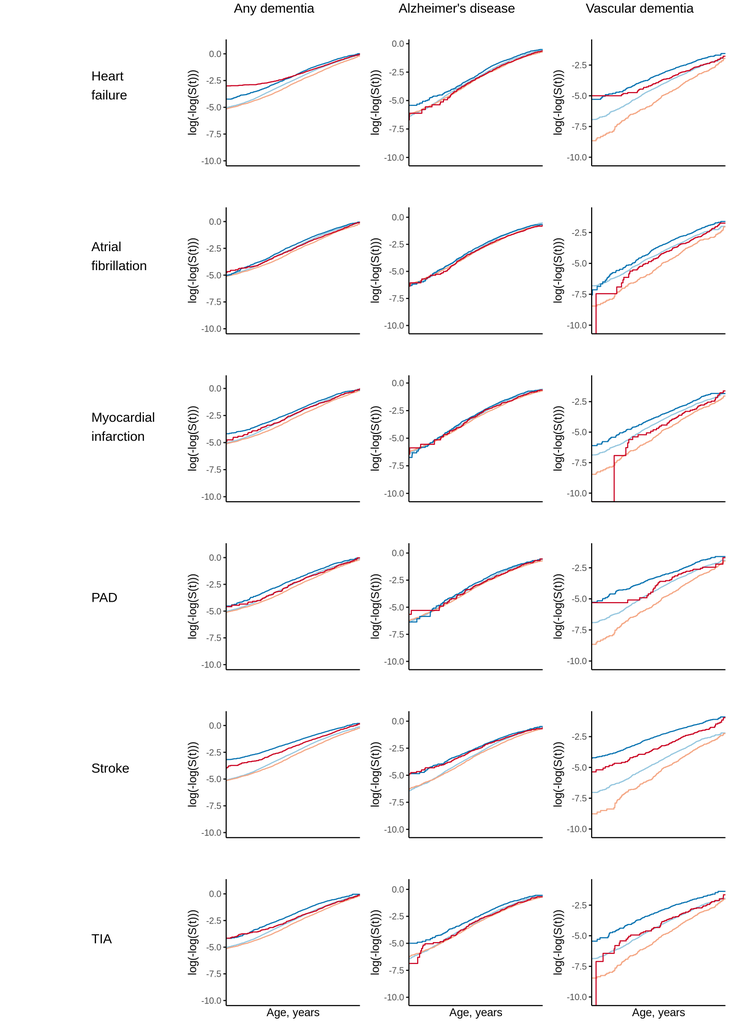

```r
nicenames <- c(DEMENTIA = "Any dementia", ALZHEIMER = "Alzheimer disase", VASCDEM = "Vascular dementia",
               AF_TDC = "Atrial\nfibrillation", OBESITY_TDC = "Obesity",
               HYPLIP_WIDE_TDC = "Hyperlipidemia", HEARTFAIL_ALLCAUSE_TDC="Heart\nfailure",
               MI_TDC = "Myocardial\ninfarction", CHRONKIDNEYDIS_TDC = "Chronic kidney disease",
               HYPERTENSION_TDC = "Hypertension", DIABETES_TDC = "Diabetes", STR_TDC = "Stroke",
               STR_EMBOLIC_TDC = "Embolic stroke", TIA_TDC = "TIA",
               AUD_TDC = "Alcohol abuse", PAD_TDC = "PAD")
fontsize <- 13
palette <- c("#92C5DE","#F4A582","#0571B0","#CA0020")
legend.labs <- c("Men: No exposure","Women: No exposure", "Men: Exposed", "Women: Exposed")

#Exposure labels
exp.labs.l <- lapply(as.list(tdc_vars2), function(var){
  text_grob(nicenames[var], just="left", size=fontsize)
})
p0 <- arrangeGrob(grobs=exp.labs.l, ncol=1)

#Dementia
ep="DEMENTIA"
var="AF_TDC"  #Without initialization loop fails, which is strange
my_formula <- str_glue("Surv(tstart, tstop, event) ~ {var}")

plots.kms <-   lapply(as.list(tdc_vars2), function(var){

  my.km <-
    ggsurvplot(km.l.d[[var]], fun="cloglog", conf.int=F, censor=F,
       xlim=c(65,95), break.x.by=5,
       title = "", xlab = "", legend="none", legend.labs=legend.labs,
       ggtheme = theme_classic(), palette = palette, size = 0.5)$plot
}) %>% setNames(as.list(tdc_vars2))
#xlab only to bottom row (TIA)
plots.kms$TIA_TDC <- plots.kms$TIA_TDC +
  xlab("Age, years")

p1 <- arrangeGrob(grobs=plots.kms, ncol=1, top=text_grob("Any dementia", size=fontsize))


#Alzheimer
ep="ALZHEIMER"
var="AF_TDC"  #Without initialization loop fails, which is strange
my_formula <- str_glue("Surv(tstart, tstop, event) ~ {var}")

plots.kms <-   lapply(as.list(tdc_vars2), function(var){

  my.km <-
    ggsurvplot(km.l.a[[var]], fun="cloglog", conf.int=F, censor=F,
       xlim=c(65,95), break.x.by=5,
       title = "", xlab = "", legend="none", legend.labs=legend.labs,
       ggtheme = theme_classic(), palette = palette, size = 0.5)$plot
}) %>% setNames(as.list(tdc_vars2))
#xlab only to bottom row (TIA)
plots.kms$TIA_TDC <- plots.kms$TIA_TDC +
  xlab("Age, years")

p2 <- arrangeGrob(grobs=plots.kms, ncol=1, top=text_grob("Alzheimer's disease", size=fontsize))



#Vascular dementia
ep="VASCDEM"
var="AF_TDC"  #Without initialization loop fails, which is strange
my_formula <- str_glue("Surv(tstart, tstop, event) ~ {var}")

plots.kms <-   lapply(as.list(tdc_vars2), function(var){

  my.km <-
    ggsurvplot(km.l.v[[var]], fun="cloglog", conf.int=F, censor=F,
       xlim=c(65,95),  break.x.by=5,
       title = "", xlab = "", legend="none", legend.labs=legend.labs,
       ggtheme = theme_classic(), palette = palette, size = 0.5)$plot
}) %>% setNames(as.list(tdc_vars2))
#xlab only to bottom row (TIA)
plots.kms$TIA_TDC <- plots.kms$TIA_TDC +
  xlab("Age, years")

p3 <- arrangeGrob(grobs=plots.kms, ncol=1, top=text_grob("Vascular dementia", size=fontsize))

#Combine all
p.grid <- arrangeGrob(p0, p1,p2,p3, ncol=4)


ggsave(file = str_glue("{fig_path}/log.grid.sex.png"), plot = p.grid, height = 14, width = 10, dpi = 300)
ggsave(file = str_glue("{fig_path}/log.grid.sex.eps"), plot = p.grid, device = cairo_ps, height = 14, width =10, dpi = 300)
```

## 2.2 Cox models

**Models**

Surv(tstart, tstop, event) ~ {var} + {oth_covs2} Interaction: Surv(tstart, tstop, event) ~ {var}*WOMEN + {oth_covs2}

```r
nicenames <- c(DEMENTIA = " Any dementia", ALZHEIMER = " Alzheimer disase", VASCDEM = " Vascular dementia",
               AF_TDC = " Atrial fibrillation", OBESITY_TDC = " Obesity",
               HYPLIP_WIDE_TDC = " Hyperlipidemia", HEARTFAIL_ALLCAUSE_TDC=" Heart failure",
               MI_TDC = " Myocardial infarction", CHRONKIDNEYDIS_TDC = " Chronic kidney disease",
               HYPERTENSION_TDC = " Hypertension", DIABETES_TDC = " Diabetes", STR_TDC = " Stroke",
               STR_EMBOLIC_TDC = " Embolic stroke", TIA_TDC = " TIA",
               AUD_TDC = " Alcohol abuse", PAD_TDC = " PAD")

#Initialize
ep <-  "DEMENTIA"
cx.table.l <- lapply(names_ep, function(x){NULL}) %>% setNames(unlist(names_ep))
#cx.full.l  <- lapply(names_ep, function(x){NULL}) %>% setNames(unlist(names_ep))

#For each outcome...
for(ep in unlist(names_ep)){

  #Covariate vector to formula format
  oth_covs2_f <- paste(c(oth_covs2), collapse = " + ")

  #Models
  cx.l.tdc.f<-
    lapply(as.list(tdc_vars2), function(var){

      my_formula <- str_glue("Surv(tstart, tstop, event) ~ {var} + {oth_covs2_f}")
      coxph(as.formula(my_formula), data=df.list.tdc.f[[ep]])

   }) %>% setNames(tdc_vars2)

   cx.l.tdc.m<-
    lapply(as.list(tdc_vars2), function(var){

      my_formula <- str_glue("Surv(tstart, tstop, event) ~ {var} + {oth_covs2_f}")
      coxph(as.formula(my_formula), data=df.list.tdc.m[[ep]])

    }) %>% setNames(tdc_vars2)

   cx.l.tdc.i<-
    lapply(as.list(tdc_vars2), function(var){

      my_formula <- str_glue("Surv(tstart, tstop, event) ~ {var}*WOMEN + {oth_covs2_f}")
      coxph(as.formula(my_formula), data=df.list.tdc[[ep]])

    }) %>% setNames(tdc_vars2)


  #Number of exposed
  nN.f <- df.list.tdc.f[[ep]] %>% extract_nN_tdc(ep, tdc_vars2)
  nN.m <- df.list.tdc.m[[ep]] %>% extract_nN_tdc(ep, tdc_vars2)

  #Tables
  tmp.table.f <-  lapply(tdc_vars2, function(var){
    coefs <- cx.l.tdc.f[[var]] %>%
      my_extr_coef(ep, var)
  }) %>% setNames(tdc_vars2) %>%
    reduce(bind_rows) %>%
    mutate(Sex="Women") %>%
    left_join(nN.f, by="names")

 tmp.table.m <-  lapply(tdc_vars2, function(var){
    coefs <- cx.l.tdc.m[[var]] %>%
      my_extr_coef(ep, var)
  }) %>% setNames(tdc_vars2) %>%
    reduce(bind_rows)%>%
    mutate(Sex="Men")%>%
    left_join(nN.m, by="names")

  tmp.table.i <-  lapply(tdc_vars2, function(var){
    coefs <- cx.l.tdc.i[[var]] %>%
      my_extr_coef(ep, ":")
  }) %>% setNames(tdc_vars2) %>%
    reduce(bind_rows) %>%
    #mutate(p.adj = p.adjust(pval, method = "fdr", n = 18)) %>%
    mutate(names=str_replace(names,"^(.*):.*","\\1")) %>%
    select(names, pval)

  #Everything colelcted
  cx.table.l[[ep]] <- bind_rows(tmp.table.f,tmp.table.m) %>%
    select(-pval) %>%
    left_join(tmp.table.i, by="names") %>%
    select(name, names, est, lower, upper, pval, nN_exp, nN_nexp, Sex) %>%
    my_tidy_est() %>%
    rename(outcome=name, variable=names, mean=est) %>%
    mutate(variable=nicenames[variable])

}
```

### 2.2.1 Dementia

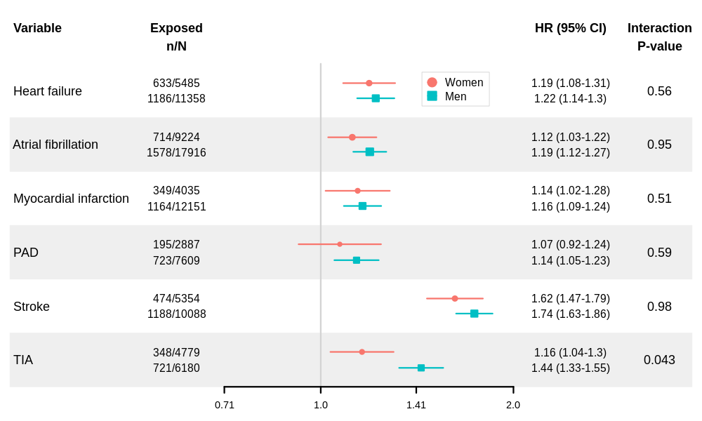

```r
ep = "DEMENTIA"

#Hack to deal with separate values
tmp <- cx.table.l[[ep]] %>%
  select(variable, Sex, est_ci, nN_exp) %>%
  pivot_wider(names_from=Sex, values_from=c("est_ci", "nN_exp")) %>%
  unite(est_ci, matches("est_ci"), sep="\n")  %>%
  unite(nN_exp, matches("nN"), sep="\n")

cx.table <- cx.table.l[[ep]] %>%
  select(outcome, variable, mean, lower, upper, pval, Sex) %>%
  left_join(tmp, by="variable")

#Forestplot&Table
font.s <- 1.3
font.l <- 1.5
lwd.bar <- 3

forest <- cx.table %>%
  group_by(Sex) %>%
  forestplot(labeltext = c(variable, nN_exp, est_ci, pval),
             legend_args = fpLegend(pos = list(x = .8, y = 0.79),
                                    gp = gpar(col = "#CCCCCC")),
             fn.ci_norm = c(fpDrawCircleCI, fpDrawNormalCI),
             #boxsize = .1, # We set the box size to better visualize the type
             line.margin = .3, # We need to add this to avoid crowding
             graph.pos=3,
             xlog=T,
             shapes_gp = fpShapesGp(default = gpar(lwd = lwd.bar)),
             txt_gp = fpTxtGp(ticks = gpar(cex=font.s-.1),
                              label=list(gpar(cex=font.l), gpar(cex=font.s), gpar(cex=font.s), gpar(cex=font.l)),
                              legend=gpar(cex=font.s),
                              summary = gpar(cex=font.l))
             ) %>%
  fp_add_header(variable= " Variable\n", nN_exp="Exposed\nn/N", est_ci = "HR (95% CI)\n", pval = "Interaction\nP-value") %>%
  fp_set_style(box = c("#F8766D", "#00BFC4"),
               line = c("#F8766D", "#00BFC4"))  %>%
  fp_set_zebra_style("#EFEFEF")


png(str_glue("{fig_path}/forest.sex.d.png"), width = 1000, height = 600)
  forest
dev.off()

pdf(str_glue("{fig_path}/forest.sex.d.pdf"), width = 12.5, height = 7.5)
  forest
dev.off()
```

### 2.2.2 Alzheimer

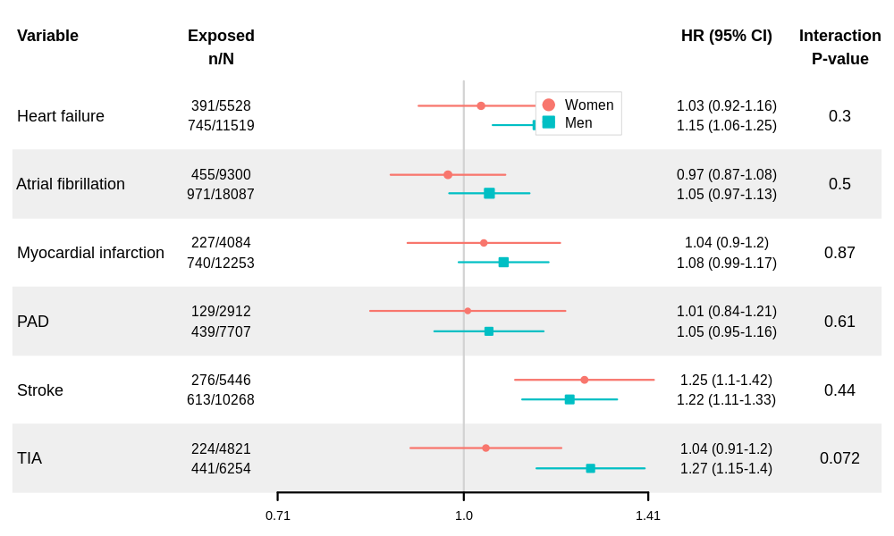

```r
ep = "ALZHEIMER"

#Hack to deal with separate values
tmp <- cx.table.l[[ep]] %>%
  select(variable, Sex, est_ci, nN_exp) %>%
  pivot_wider(names_from=Sex, values_from=c("est_ci", "nN_exp")) %>%
  unite(est_ci, matches("est_ci"), sep="\n")  %>%
  unite(nN_exp, matches("nN"), sep="\n")

cx.table <- cx.table.l[[ep]] %>%
  select(outcome, variable, mean, lower, upper, pval, Sex) %>%
  left_join(tmp, by="variable")

#Forestplot&Table
font.s <- 1.3
font.l <- 1.5
lwd.bar <- 3

forest <- cx.table %>%
  group_by(Sex) %>%
  forestplot(labeltext = c(variable, nN_exp, est_ci, pval),
             legend_args = fpLegend(pos = list(x = .8, y = 0.79),
                                    gp = gpar(col = "#CCCCCC")),
             fn.ci_norm = c(fpDrawCircleCI, fpDrawNormalCI),
             #boxsize = .1, # We set the box size to better visualize the type
             line.margin = .3, # We need to add this to avoid crowding
             graph.pos=3,
             xlog=T,
             shapes_gp = fpShapesGp(default = gpar(lwd = lwd.bar)),
             txt_gp = fpTxtGp(ticks = gpar(cex=font.s-.1),
                              label=list(gpar(cex=font.l), gpar(cex=font.s), gpar(cex=font.s), gpar(cex=font.l)),
                              legend=gpar(cex=font.s),
                              summary = gpar(cex=font.l))
             ) %>%
  fp_add_header(variable= " Variable\n", nN_exp="Exposed\nn/N", est_ci = "HR (95% CI)\n", pval = "Interaction\nP-value") %>%
  fp_set_style(box = c("#F8766D", "#00BFC4"),
               line = c("#F8766D", "#00BFC4"))  %>%
  fp_set_zebra_style("#EFEFEF")


png(str_glue("{fig_path}/forest.sex.a.png"), width = 1000, height = 600)
  forest
dev.off()

pdf(str_glue("{fig_path}/forest.sex.a.pdf"), width = 12.5, height = 7.5)
  forest
dev.off()
```

### 2.2.3 Vascular dementia

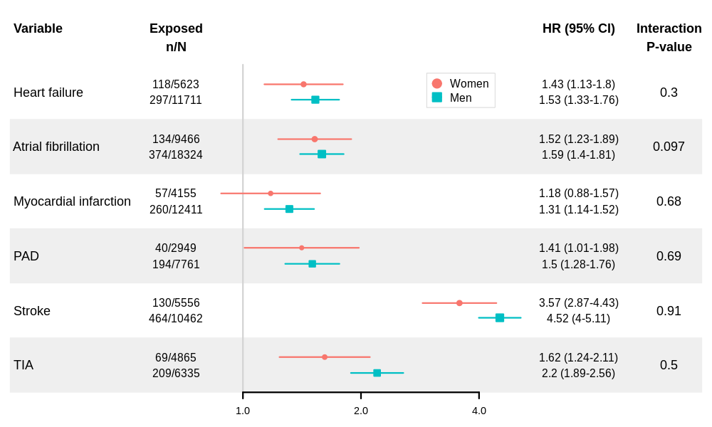

```r
ep = "VASCDEM"

#Hack to deal with separate values
tmp <- cx.table.l[[ep]] %>%
  select(variable, Sex, est_ci, nN_exp) %>%
  pivot_wider(names_from=Sex, values_from=c("est_ci", "nN_exp")) %>%
  unite(est_ci, matches("est_ci"), sep="\n")  %>%
  unite(nN_exp, matches("nN"), sep="\n")

cx.table <- cx.table.l[[ep]] %>%
  select(outcome, variable, mean, lower, upper, pval, Sex) %>%
  left_join(tmp, by="variable")

#Forestplot&Table
font.s <- 1.3
font.l <- 1.5
lwd.bar <- 3

forest <- cx.table %>%
  group_by(Sex) %>%
  forestplot(labeltext = c(variable, nN_exp, est_ci, pval),
             legend_args = fpLegend(pos = list(x = .8, y = 0.79),
                                    gp = gpar(col = "#CCCCCC")),
             fn.ci_norm = c(fpDrawCircleCI, fpDrawNormalCI),
             #boxsize = .1, # We set the box size to better visualize the type
             line.margin = .3, # We need to add this to avoid crowding
             graph.pos=3,
             xlog=T,
             shapes_gp = fpShapesGp(default = gpar(lwd = lwd.bar)),
             txt_gp = fpTxtGp(ticks = gpar(cex=font.s-.1),
                              label=list(gpar(cex=font.l), gpar(cex=font.s), gpar(cex=font.s), gpar(cex=font.l)),
                              legend=gpar(cex=font.s),
                              summary = gpar(cex=font.l))
             ) %>%
  fp_add_header(variable= " Variable\n", nN_exp="Exposed\nn/N", est_ci = "HR (95% CI)\n", pval = "Interaction\nP-value") %>%
  fp_set_style(box = c("#F8766D", "#00BFC4"),
               line = c("#F8766D", "#00BFC4"))  %>%
  fp_set_zebra_style("#EFEFEF")


png(str_glue("{fig_path}/forest.sex.v.png"), width = 1000, height = 600)
  forest
dev.off()

pdf(str_glue("{fig_path}/forest.sex.v.pdf"), width = 14, height = 8.4)
  forest
dev.off()
```